# How you Lose your Money in the Roulette

Wenying Gu

9/3/2019

### Email: wenying.gu@vanderbilt.edu

## What is the Roulette?

[figure not shown]

A roulette table composed of 38 (or 37) evenly sized pockets on a wheel. The pockets are colored red, black, or green. The pockets are also numbered. Roulette is a game of chance in which a pocket is randomly selected. Gamblers may wager on several aspects of the outcome. For example, one may place a wager that the randomly selected pocket will be red or odd numbered or will be a specific number.

## Description of parameters:

This is a single play of the roulette. Some concepts have been defined as following:

#’B number: the budget; #’W number: the budget threshold for successfully stoping; #’L number: the maximum number of plays; #’M number: the casino wager limit; #‘plays integer: the number of plays executed;

## One play

We will define the wager and then spin the wheel for one time. It will result in a new wager for us. We can win or lose the money after plays. This code will show both conditions.

```r
library(dplyr)

one_play <- function(state){

    # Wager
    proposed_wager <- ifelse(state$previous_win, 1, 2*state$previous_wager)
    wager <- min(proposed_wager, state$M, state$B)

    # Spin of the wheel
    red <- rbinom(1,1,18/38)

    # Update state
    state$plays <- state$plays + 1
    state$previous_wager <- wager
    if(red){
      # WIN
      state$B <- state$B + wager
      state$previous_win <- TRUE
    }else{
      # LOSE
      state$B <- state$B - wager
      state$previous_win <- FALSE
    }
  state
}
```

## Stopping rule

Play roulette to either bankruptcy, success, or play limits

B number, the starting budget W number, the budget threshold for successfully stoping L number, the maximum number of plays M number, the casino wager limit A vector of budget values calculated after each play.

```r
stop_play <- function(state){
  if(state$B <= 0) return(TRUE)
  if(state$plays >= state$L) return(TRUE)
  if(state$B >= state$W) return(TRUE)
  FALSE
}


one_series <- function(
    B = 200
  , W = 300
  , L = 1000
  , M = 100
){

  # initial state
  state <- list(
    B = B
  , W = W
  , L = L
  , M = M
  , plays = 0
  , previous_wager = 0
  , previous_win = TRUE
  )

  # vector to store budget over series of plays
  budget <- rep(NA, L)

  # For loop of plays
  for(i in 1:L){
    new_state <- state %>% one_play
    budget[i] <- new_state$B
    if(new_state %>% stop_play){
      return(budget[1:i])
    }
    state <- new_state
  }
  budget
}
```

## Walk out money

After a series of plays, player will walk out the cacino based on the stopping rules defined above. The moeny they left can be calculate as following codes to estimate average earnings (walk out money).

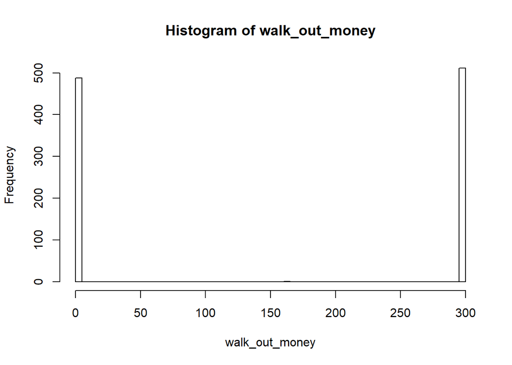

```r
# helper function
get_last <- function(x) x[length(x)]

# Simulation
walk_out_money <- rep(NA, 1000)
for(j in seq_along(walk_out_money)){
  walk_out_money[j] <- one_series(B = 200, W = 300, L = 1000, M = 100) %>% get_last
}

# Walk out money distribution
hist(walk_out_money, breaks = 100)
```

```r
# Estimated probability of walking out with extra cash
mean(walk_out_money > 200)
```

```
## [1] 0.511
```

```r
# Estimated earnings
mean(walk_out_money - 200)
```

```
## [1] -46.538
```

# Homework Question

## Average earnings

If the gambler’s starting budget is 200, and budget threshold for successfully stoping is 300. He could only play at most 1000 times. Besides the casino wager limits is 100. We defined our B,W,L,M and run the simulation to get a walk out money when the gambler stop playing. And Earnings= would out money- starting budget which is 200. Here is the graph that we have.

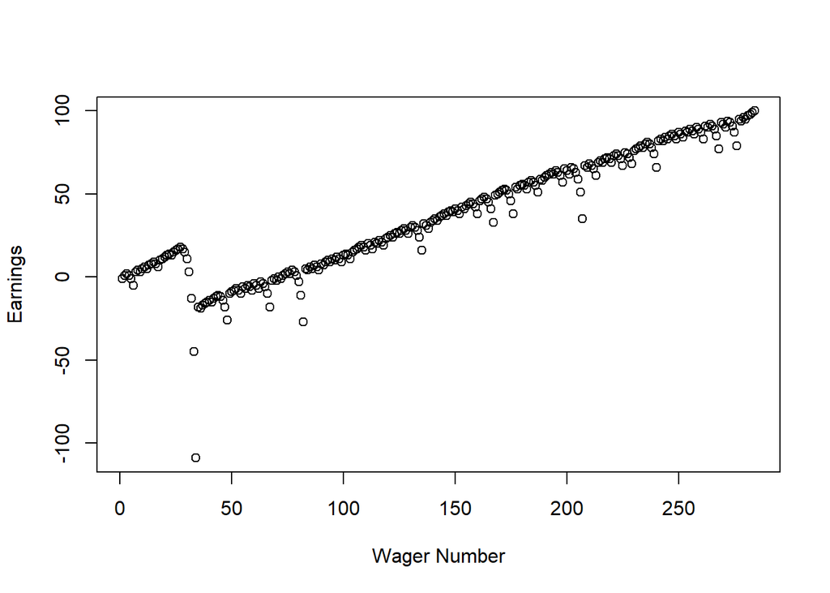

```r
Earnings <- one_series(B = 200, W = 300, L = 1000, M = 100) - 200

plot(Earnings, xlab = "Wager Number" )
```

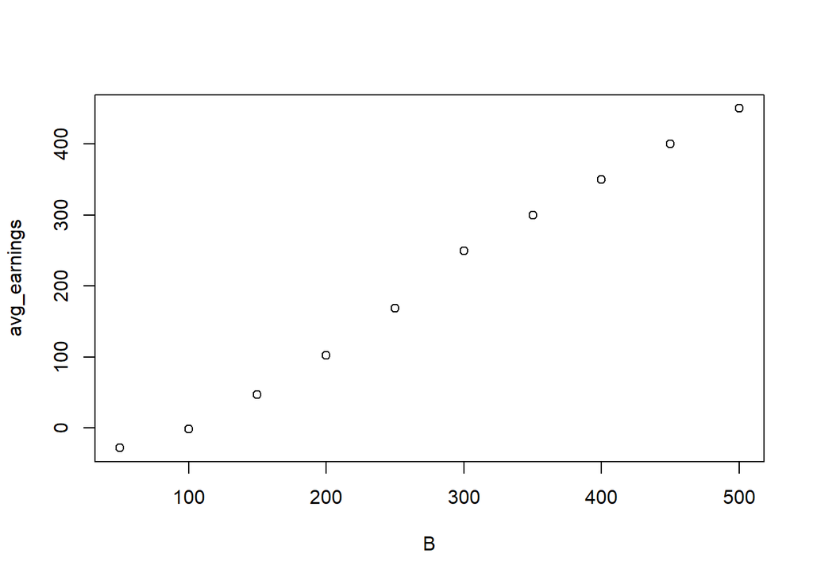

```r
B <- seq(50,500,50)
avg_earnings <- rep(NA, length(B))
for(i in 1:length(B)){
  walk_out_money <- rep(NA, 1000)
  for(j in seq_along(walk_out_money)){
    walk_out_money[j] <- one_series(B = B[i], W = 300, L = 1000, M = 100) %>% get_last
  }
  avg_earnings[i] <- (mean(walk_out_money)-B)
}

plot(B, avg_earnings)
```

## Estimate the average number of plays before stopping.

To calculate the average number of plays before stopping, we add length to the simulation and get average play number is around 200.

```r
play_times <- rep(NA, 1000)
for(j in seq_along(play_times)){
  play_times[j] <- one_series(B = 200, W = 300, L = 1000, M = 100) %>% length
}

avg_play_times<- mean(play_times)
avg_play_times
```

```
## [1] 201.161
```

## Limitation of the simulation

It only runs 1000 times. This simulation doesn’t count the back box cases in. In the reality, things may be more comlicated and unpredictable.